# Risk Factor Analysis

## Outcome Variable

**Outcome Variable:** stunted

## Predictor Variables

**Intervention Variable:** hfoodsec

**Adjustment Set:**

- arm
- sex
- W_mage
- meducyrs
- feducyrs
- hhwealth_quart
- vagbrth
- W_nrooms
- W_nchldlt5
- brthmon
- W_parity
- impfloor
- impsan
- safeh20
- delta_W_mage
- delta_meducyrs
- delta_feducyrs
- delta_hhwealth_quart
- delta_vagbrth
- delta_W_nrooms
- delta_W_nchldlt5
- delta_brthmon
- delta_W_parity
- delta_impfloor
- delta_impsan
- delta_safeh20

## Stratifying Variables

The analysis was stratified on these variable(s):

- agecat
- studyid
- country

## Data Summary

| agecat | studyid | country | hfoodsec | stunted | n_cell | n |
| --- | --- | --- | --- | --- | --- | --- |
| Birth | ki0047075b-MAL-ED | BANGLADESH | Food Secure | 0 | 133 | 188 |
| Birth | ki0047075b-MAL-ED | BANGLADESH | Food Secure | 1 | 24 | 188 |
| Birth | ki0047075b-MAL-ED | BANGLADESH | Mildly Food Insecure | 0 | 3 | 188 |
| Birth | ki0047075b-MAL-ED | BANGLADESH | Mildly Food Insecure | 1 | 1 | 188 |
| Birth | ki0047075b-MAL-ED | BANGLADESH | Moderately Food Insecure | 0 | 19 | 188 |
| Birth | ki0047075b-MAL-ED | BANGLADESH | Moderately Food Insecure | 1 | 3 | 188 |
| Birth | ki0047075b-MAL-ED | BANGLADESH | Severely Food Insecure | 0 | 4 | 188 |
| Birth | ki0047075b-MAL-ED | BANGLADESH | Severely Food Insecure | 1 | 1 | 188 |
| 6 months | ki0047075b-MAL-ED | BANGLADESH | Food Secure | 0 | 128 | 193 |
| 6 months | ki0047075b-MAL-ED | BANGLADESH | Food Secure | 1 | 32 | 193 |
| 6 months | ki0047075b-MAL-ED | BANGLADESH | Mildly Food Insecure | 0 | 2 | 193 |
| 6 months | ki0047075b-MAL-ED | BANGLADESH | Mildly Food Insecure | 1 | 2 | 193 |
| 6 months | ki0047075b-MAL-ED | BANGLADESH | Moderately Food Insecure | 0 | 21 | 193 |
| 6 months | ki0047075b-MAL-ED | BANGLADESH | Moderately Food Insecure | 1 | 2 | 193 |
| 6 months | ki0047075b-MAL-ED | BANGLADESH | Severely Food Insecure | 0 | 4 | 193 |
| 6 months | ki0047075b-MAL-ED | BANGLADESH | Severely Food Insecure | 1 | 2 | 193 |
| 24 months | ki0047075b-MAL-ED | BANGLADESH | Food Secure | 0 | 90 | 194 |
| 24 months | ki0047075b-MAL-ED | BANGLADESH | Food Secure | 1 | 71 | 194 |
| 24 months | ki0047075b-MAL-ED | BANGLADESH | Mildly Food Insecure | 0 | 1 | 194 |
| 24 months | ki0047075b-MAL-ED | BANGLADESH | Mildly Food Insecure | 1 | 3 | 194 |
| 24 months | ki0047075b-MAL-ED | BANGLADESH | Moderately Food Insecure | 0 | 10 | 194 |
| 24 months | ki0047075b-MAL-ED | BANGLADESH | Moderately Food Insecure | 1 | 13 | 194 |
| 24 months | ki0047075b-MAL-ED | BANGLADESH | Severely Food Insecure | 0 | 2 | 194 |
| 24 months | ki0047075b-MAL-ED | BANGLADESH | Severely Food Insecure | 1 | 4 | 194 |
| Birth | ki0047075b-MAL-ED | BRAZIL | Mildly Food Insecure | 0 | 10 | 105 |
| Birth | ki0047075b-MAL-ED | BRAZIL | Mildly Food Insecure | 1 | 1 | 105 |
| Birth | ki0047075b-MAL-ED | BRAZIL | Moderately Food Insecure | 0 | 46 | 105 |
| Birth | ki0047075b-MAL-ED | BRAZIL | Moderately Food Insecure | 1 | 8 | 105 |
| Birth | ki0047075b-MAL-ED | BRAZIL | Severely Food Insecure | 0 | 38 | 105 |
| Birth | ki0047075b-MAL-ED | BRAZIL | Severely Food Insecure | 1 | 2 | 105 |

[output cut: 210 more lines]

The following strata were considered:

- agecat: 24 months, studyid: ki0047075b-MAL-ED, country: BANGLADESH
- agecat: 24 months, studyid: ki0047075b-MAL-ED, country: BRAZIL
- agecat: 24 months, studyid: ki0047075b-MAL-ED, country: INDIA
- agecat: 24 months, studyid: ki0047075b-MAL-ED, country: NEPAL
- agecat: 24 months, studyid: ki0047075b-MAL-ED, country: PERU
- agecat: 24 months, studyid: ki0047075b-MAL-ED, country: SOUTH AFRICA
- agecat: 24 months, studyid: ki1017093-NIH-Birth, country: BANGLADESH
- agecat: 24 months, studyid: ki1017093c-NIH-Crypto, country: BANGLADESH
- agecat: 24 months, studyid: ki1113344-GMS-Nepal, country: NEPAL
- agecat: 24 months, studyid: kiGH5241-JiVitA-3, country: BANGLADESH
- agecat: 24 months, studyid: kiGH5241-JiVitA-4, country: BANGLADESH
- agecat: 6 months, studyid: ki0047075b-MAL-ED, country: BANGLADESH
- agecat: 6 months, studyid: ki0047075b-MAL-ED, country: BRAZIL
- agecat: 6 months, studyid: ki0047075b-MAL-ED, country: INDIA
- agecat: 6 months, studyid: ki0047075b-MAL-ED, country: NEPAL
- agecat: 6 months, studyid: ki0047075b-MAL-ED, country: PERU
- agecat: 6 months, studyid: ki0047075b-MAL-ED, country: SOUTH AFRICA
- agecat: 6 months, studyid: ki1017093-NIH-Birth, country: BANGLADESH
- agecat: 6 months, studyid: ki1017093c-NIH-Crypto, country: BANGLADESH
- agecat: 6 months, studyid: ki1113344-GMS-Nepal, country: NEPAL
- agecat: 6 months, studyid: kiGH5241-JiVitA-3, country: BANGLADESH
- agecat: 6 months, studyid: kiGH5241-JiVitA-4, country: BANGLADESH
- agecat: Birth, studyid: ki0047075b-MAL-ED, country: BANGLADESH
- agecat: Birth, studyid: ki0047075b-MAL-ED, country: BRAZIL
- agecat: Birth, studyid: ki0047075b-MAL-ED, country: INDIA
- agecat: Birth, studyid: ki0047075b-MAL-ED, country: NEPAL
- agecat: Birth, studyid: ki0047075b-MAL-ED, country: PERU
- agecat: Birth, studyid: ki0047075b-MAL-ED, country: SOUTH AFRICA
- agecat: Birth, studyid: ki1017093-NIH-Birth, country: BANGLADESH
- agecat: Birth, studyid: ki1017093c-NIH-Crypto, country: BANGLADESH
- agecat: Birth, studyid: kiGH5241-JiVitA-3, country: BANGLADESH
- agecat: Birth, studyid: kiGH5241-JiVitA-4, country: BANGLADESH

### Dropped Strata

Some strata were dropped due to rare outcomes:

- agecat: Birth, studyid: ki0047075b-MAL-ED, country: BANGLADESH
- agecat: 6 months, studyid: ki0047075b-MAL-ED, country: BANGLADESH
- agecat: 24 months, studyid: ki0047075b-MAL-ED, country: BANGLADESH
- agecat: Birth, studyid: ki0047075b-MAL-ED, country: BRAZIL
- agecat: 6 months, studyid: ki0047075b-MAL-ED, country: BRAZIL
- agecat: 24 months, studyid: ki0047075b-MAL-ED, country: BRAZIL
- agecat: Birth, studyid: ki0047075b-MAL-ED, country: INDIA
- agecat: 6 months, studyid: ki0047075b-MAL-ED, country: INDIA
- agecat: 24 months, studyid: ki0047075b-MAL-ED, country: INDIA
- agecat: Birth, studyid: ki0047075b-MAL-ED, country: NEPAL
- agecat: 6 months, studyid: ki0047075b-MAL-ED, country: NEPAL
- agecat: 24 months, studyid: ki0047075b-MAL-ED, country: NEPAL
- agecat: Birth, studyid: ki0047075b-MAL-ED, country: PERU
- agecat: Birth, studyid: ki0047075b-MAL-ED, country: SOUTH AFRICA
- agecat: 6 months, studyid: ki0047075b-MAL-ED, country: SOUTH AFRICA
- agecat: 24 months, studyid: ki0047075b-MAL-ED, country: SOUTH AFRICA
- agecat: 6 months, studyid: ki1017093-NIH-Birth, country: BANGLADESH
- agecat: 24 months, studyid: ki1017093-NIH-Birth, country: BANGLADESH
- agecat: Birth, studyid: ki1017093-NIH-Birth, country: BANGLADESH
- agecat: Birth, studyid: ki1017093c-NIH-Crypto, country: BANGLADESH
- agecat: 6 months, studyid: ki1113344-GMS-Nepal, country: NEPAL

## Methods Detail

We’re interested in the causal parameters $E[Y_a]$ for all values of $a \in \mathcal{A}$. These parameters represent the mean outcome if, possibly contrary to fact, we intervened to set all units to have $A=a$. Under the randomization and positivity assumptions, these are identified by the statistical parameters $\psi_a=E_W[E_{Y|A,W}(Y|A=a,W)]$. In addition, we’re interested in the mean of $Y$, $E[Y]$ under no intervention (the observed mean). We will estimate these parameters by using SuperLearner to fit the relevant likelihood factors – $E_{Y|A,W}(Y|A=a,W)$ and $p(A=a|W)$, and then updating our likelihood fit using a joint TMLE.

For unadjusted analyses ($W=\{\}$), initial likelihoods were estimated using Lrnr_glm to estimate the simple $E(Y|A)$ and Lrnr_mean to estimate $p(A)$. For adjusted analyses, a small library containing Lrnr_glmnet, Lrnr_xgboost, and Lrnr_mean was used.

Having estimated these parameters, we will then use the delta method to estimate relative risks and attributable risks relative to a prespecified baseline level of $A$.

[output not shown]

[output not shown]

[output not shown]

[output not shown]

[output not shown]

[output not shown]

# Results Detail

## Results Plots

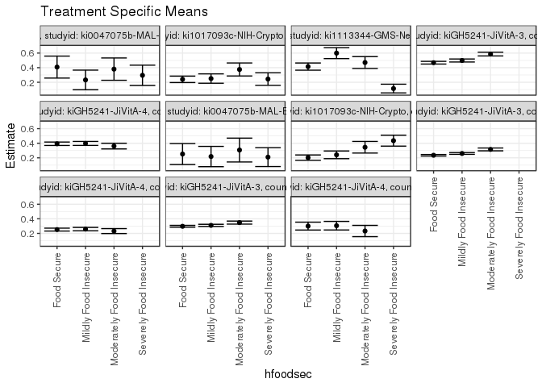

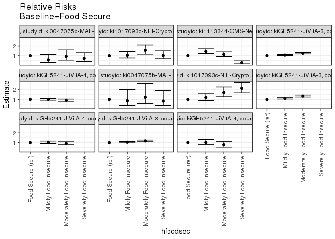

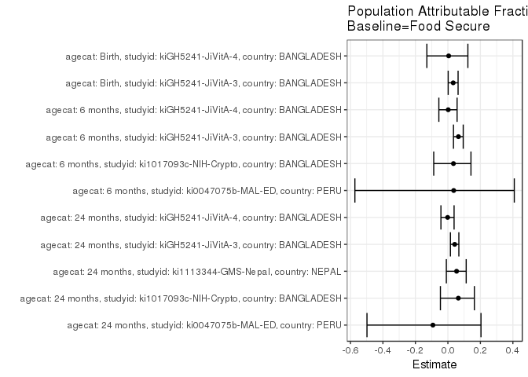

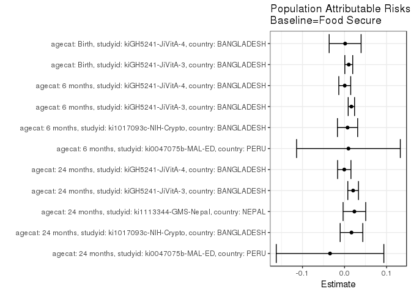

## Results Table

### Parameter: TSM

| agecat | studyid | country | intervention_level | baseline_level | estimate | ci_lower | ci_upper |
| --- | --- | --- | --- | --- | --- | --- | --- |
| Birth | kiGH5241-JiVitA-3 | BANGLADESH | Food Secure | NA | 0.2972106 | 0.2845538 | 0.3098674 |
| Birth | kiGH5241-JiVitA-3 | BANGLADESH | Mildly Food Insecure | NA | 0.3099165 | 0.2951932 | 0.3246398 |
| Birth | kiGH5241-JiVitA-3 | BANGLADESH | Moderately Food Insecure | NA | 0.3479812 | 0.3270629 | 0.3688995 |
| Birth | kiGH5241-JiVitA-4 | BANGLADESH | Food Secure | NA | 0.3001546 | 0.2462476 | 0.3540616 |
| Birth | kiGH5241-JiVitA-4 | BANGLADESH | Mildly Food Insecure | NA | 0.3056781 | 0.2469352 | 0.3644209 |
| Birth | kiGH5241-JiVitA-4 | BANGLADESH | Moderately Food Insecure | NA | 0.2324769 | 0.1550984 | 0.3098553 |
| 6 months | ki0047075b-MAL-ED | PERU | Food Secure | NA | 0.2519312 | 0.1081904 | 0.3956719 |
| 6 months | ki0047075b-MAL-ED | PERU | Mildly Food Insecure | NA | 0.2178645 | 0.0788201 | 0.3569090 |
| 6 months | ki0047075b-MAL-ED | PERU | Moderately Food Insecure | NA | 0.3068743 | 0.1434286 | 0.4703201 |
| 6 months | ki0047075b-MAL-ED | PERU | Severely Food Insecure | NA | 0.2100259 | 0.0806619 | 0.3393899 |
| 6 months | ki1017093c-NIH-Crypto | BANGLADESH | Food Secure | NA | 0.2026229 | 0.1659002 | 0.2393457 |
| 6 months | ki1017093c-NIH-Crypto | BANGLADESH | Mildly Food Insecure | NA | 0.2412874 | 0.1886306 | 0.2939442 |
| 6 months | ki1017093c-NIH-Crypto | BANGLADESH | Moderately Food Insecure | NA | 0.3450789 | 0.2656943 | 0.4244634 |
| 6 months | ki1017093c-NIH-Crypto | BANGLADESH | Severely Food Insecure | NA | 0.4354307 | 0.3603348 | 0.5105265 |
| 6 months | kiGH5241-JiVitA-3 | BANGLADESH | Food Secure | NA | 0.2351543 | 0.2245508 | 0.2457578 |
| 6 months | kiGH5241-JiVitA-3 | BANGLADESH | Mildly Food Insecure | NA | 0.2600387 | 0.2477186 | 0.2723588 |
| 6 months | kiGH5241-JiVitA-3 | BANGLADESH | Moderately Food Insecure | NA | 0.3154566 | 0.2960993 | 0.3348140 |
| 6 months | kiGH5241-JiVitA-4 | BANGLADESH | Food Secure | NA | 0.2521451 | 0.2320865 | 0.2722037 |
| 6 months | kiGH5241-JiVitA-4 | BANGLADESH | Mildly Food Insecure | NA | 0.2588789 | 0.2358911 | 0.2818667 |
| 6 months | kiGH5241-JiVitA-4 | BANGLADESH | Moderately Food Insecure | NA | 0.2317836 | 0.1978565 | 0.2657106 |
| 24 months | ki0047075b-MAL-ED | PERU | Food Secure | NA | 0.4083078 | 0.2577527 | 0.5588629 |
| 24 months | ki0047075b-MAL-ED | PERU | Mildly Food Insecure | NA | 0.2320582 | 0.0973316 | 0.3667848 |
| 24 months | ki0047075b-MAL-ED | PERU | Moderately Food Insecure | NA | 0.3802402 | 0.2274408 | 0.5330396 |
| 24 months | ki0047075b-MAL-ED | PERU | Severely Food Insecure | NA | 0.2952896 | 0.1562512 | 0.4343279 |
| 24 months | ki1017093c-NIH-Crypto | BANGLADESH | Food Secure | NA | 0.2403038 | 0.1961197 | 0.2844879 |
| 24 months | ki1017093c-NIH-Crypto | BANGLADESH | Mildly Food Insecure | NA | 0.2508748 | 0.1868670 | 0.3148827 |
| 24 months | ki1017093c-NIH-Crypto | BANGLADESH | Moderately Food Insecure | NA | 0.3754021 | 0.2863577 | 0.4644465 |
| 24 months | ki1017093c-NIH-Crypto | BANGLADESH | Severely Food Insecure | NA | 0.2440395 | 0.1581315 | 0.3299476 |
| 24 months | ki1113344-GMS-Nepal | NEPAL | Food Secure | NA | 0.4150699 | 0.3660170 | 0.4641228 |
| 24 months | ki1113344-GMS-Nepal | NEPAL | Mildly Food Insecure | NA | 0.5994583 | 0.5244633 | 0.6744533 |
| 24 months | ki1113344-GMS-Nepal | NEPAL | Moderately Food Insecure | NA | 0.4707849 | 0.3896259 | 0.5519438 |
| 24 months | ki1113344-GMS-Nepal | NEPAL | Severely Food Insecure | NA | 0.1138674 | 0.0543505 | 0.1733843 |
| 24 months | kiGH5241-JiVitA-3 | BANGLADESH | Food Secure | NA | 0.4682306 | 0.4499079 | 0.4865532 |
| 24 months | kiGH5241-JiVitA-3 | BANGLADESH | Mildly Food Insecure | NA | 0.4983901 | 0.4777499 | 0.5190303 |
| 24 months | kiGH5241-JiVitA-3 | BANGLADESH | Moderately Food Insecure | NA | 0.5863895 | 0.5608339 | 0.6119451 |
| 24 months | kiGH5241-JiVitA-4 | BANGLADESH | Food Secure | NA | 0.3929478 | 0.3695297 | 0.4163659 |
| 24 months | kiGH5241-JiVitA-4 | BANGLADESH | Mildly Food Insecure | NA | 0.3973024 | 0.3701739 | 0.4244309 |
| 24 months | kiGH5241-JiVitA-4 | BANGLADESH | Moderately Food Insecure | NA | 0.3608521 | 0.3218036 | 0.3999006 |

### Parameter: E(Y)

| agecat | studyid | country | intervention_level | baseline_level | estimate | ci_lower | ci_upper |
| --- | --- | --- | --- | --- | --- | --- | --- |
| Birth | kiGH5241-JiVitA-3 | BANGLADESH | NA | NA | 0.3072590 | 0.2982359 | 0.3162822 |
| Birth | kiGH5241-JiVitA-4 | BANGLADESH | NA | NA | 0.3015873 | 0.2659035 | 0.3372711 |
| 6 months | ki0047075b-MAL-ED | PERU | NA | NA | 0.2612613 | 0.1791629 | 0.3433597 |
| 6 months | ki1017093c-NIH-Crypto | BANGLADESH | NA | NA | 0.2097902 | 0.1799252 | 0.2396552 |
| 6 months | kiGH5241-JiVitA-3 | BANGLADESH | NA | NA | 0.2514442 | 0.2432971 | 0.2595914 |
| 6 months | kiGH5241-JiVitA-4 | BANGLADESH | NA | NA | 0.2526601 | 0.2384064 | 0.2669139 |
| 24 months | ki0047075b-MAL-ED | PERU | NA | NA | 0.3738318 | 0.2817277 | 0.4659358 |
| 24 months | ki1017093c-NIH-Crypto | BANGLADESH | NA | NA | 0.2568093 | 0.2190047 | 0.2946140 |
| 24 months | ki1113344-GMS-Nepal | NEPAL | NA | NA | 0.4385246 | 0.3944543 | 0.4825949 |
| 24 months | kiGH5241-JiVitA-3 | BANGLADESH | NA | NA | 0.4886779 | 0.4752340 | 0.5021218 |
| 24 months | kiGH5241-JiVitA-4 | BANGLADESH | NA | NA | 0.3923191 | 0.3753084 | 0.4093298 |

### Parameter: RR

| agecat | studyid | country | intervention_level | baseline_level | estimate | ci_lower | ci_upper |
| --- | --- | --- | --- | --- | --- | --- | --- |
| Birth | kiGH5241-JiVitA-3 | BANGLADESH | Food Secure | Food Secure | 1.0000000 | 1.0000000 | 1.0000000 |
| Birth | kiGH5241-JiVitA-3 | BANGLADESH | Mildly Food Insecure | Food Secure | 1.0427504 | 0.9802597 | 1.1092249 |
| Birth | kiGH5241-JiVitA-3 | BANGLADESH | Moderately Food Insecure | Food Secure | 1.1708236 | 1.0875603 | 1.2604616 |
| Birth | kiGH5241-JiVitA-4 | BANGLADESH | Food Secure | Food Secure | 1.0000000 | 1.0000000 | 1.0000000 |
| Birth | kiGH5241-JiVitA-4 | BANGLADESH | Mildly Food Insecure | Food Secure | 1.0184019 | 0.7847635 | 1.3215987 |
| Birth | kiGH5241-JiVitA-4 | BANGLADESH | Moderately Food Insecure | Food Secure | 0.7745237 | 0.5314378 | 1.1288000 |
| 6 months | ki0047075b-MAL-ED | PERU | Food Secure | Food Secure | 1.0000000 | 1.0000000 | 1.0000000 |
| 6 months | ki0047075b-MAL-ED | PERU | Mildly Food Insecure | Food Secure | 0.8647780 | 0.3698093 | 2.0222341 |
| 6 months | ki0047075b-MAL-ED | PERU | Moderately Food Insecure | Food Secure | 1.2180881 | 0.5615308 | 2.6423105 |
| 6 months | ki0047075b-MAL-ED | PERU | Severely Food Insecure | Food Secure | 0.8336639 | 0.3601216 | 1.9298913 |
| 6 months | ki1017093c-NIH-Crypto | BANGLADESH | Food Secure | Food Secure | 1.0000000 | 1.0000000 | 1.0000000 |
| 6 months | ki1017093c-NIH-Crypto | BANGLADESH | Mildly Food Insecure | Food Secure | 1.1908198 | 0.8972517 | 1.5804393 |
| 6 months | ki1017093c-NIH-Crypto | BANGLADESH | Moderately Food Insecure | Food Secure | 1.7030591 | 1.2715648 | 2.2809772 |
| 6 months | ki1017093c-NIH-Crypto | BANGLADESH | Severely Food Insecure | Food Secure | 2.1489702 | 1.6744344 | 2.7579897 |
| 6 months | kiGH5241-JiVitA-3 | BANGLADESH | Food Secure | Food Secure | 1.0000000 | 1.0000000 | 1.0000000 |
| 6 months | kiGH5241-JiVitA-3 | BANGLADESH | Mildly Food Insecure | Food Secure | 1.1058216 | 1.0408864 | 1.1748079 |
| 6 months | kiGH5241-JiVitA-3 | BANGLADESH | Moderately Food Insecure | Food Secure | 1.3414879 | 1.2443231 | 1.4462399 |
| 6 months | kiGH5241-JiVitA-4 | BANGLADESH | Food Secure | Food Secure | 1.0000000 | 1.0000000 | 1.0000000 |
| 6 months | kiGH5241-JiVitA-4 | BANGLADESH | Mildly Food Insecure | Food Secure | 1.0267062 | 0.9108903 | 1.1572477 |
| 6 months | kiGH5241-JiVitA-4 | BANGLADESH | Moderately Food Insecure | Food Secure | 0.9192468 | 0.7786771 | 1.0851927 |
| 24 months | ki0047075b-MAL-ED | PERU | Food Secure | Food Secure | 1.0000000 | 1.0000000 | 1.0000000 |
| 24 months | ki0047075b-MAL-ED | PERU | Mildly Food Insecure | Food Secure | 0.5683413 | 0.2890811 | 1.1173745 |
| 24 months | ki0047075b-MAL-ED | PERU | Moderately Food Insecure | Food Secure | 0.9312587 | 0.5427638 | 1.5978272 |
| 24 months | ki0047075b-MAL-ED | PERU | Severely Food Insecure | Food Secure | 0.7232033 | 0.4010031 | 1.3042868 |
| 24 months | ki1017093c-NIH-Crypto | BANGLADESH | Food Secure | Food Secure | 1.0000000 | 1.0000000 | 1.0000000 |
| 24 months | ki1017093c-NIH-Crypto | BANGLADESH | Mildly Food Insecure | Food Secure | 1.0439903 | 0.7654859 | 1.4238221 |
| 24 months | ki1017093c-NIH-Crypto | BANGLADESH | Moderately Food Insecure | Food Secure | 1.5621980 | 1.1608527 | 2.1023015 |
| 24 months | ki1017093c-NIH-Crypto | BANGLADESH | Severely Food Insecure | Food Secure | 1.0155459 | 0.6848100 | 1.5060141 |
| 24 months | ki1113344-GMS-Nepal | NEPAL | Food Secure | Food Secure | 1.0000000 | 1.0000000 | 1.0000000 |
| 24 months | ki1113344-GMS-Nepal | NEPAL | Mildly Food Insecure | Food Secure | 1.4442347 | 1.2177468 | 1.7128469 |
| 24 months | ki1113344-GMS-Nepal | NEPAL | Moderately Food Insecure | Food Secure | 1.1342304 | 0.9217407 | 1.3957056 |
| 24 months | ki1113344-GMS-Nepal | NEPAL | Severely Food Insecure | Food Secure | 0.2743330 | 0.1607250 | 0.4682446 |
| 24 months | kiGH5241-JiVitA-3 | BANGLADESH | Food Secure | Food Secure | 1.0000000 | 1.0000000 | 1.0000000 |
| 24 months | kiGH5241-JiVitA-3 | BANGLADESH | Mildly Food Insecure | Food Secure | 1.0644118 | 1.0096089 | 1.1221894 |
| 24 months | kiGH5241-JiVitA-3 | BANGLADESH | Moderately Food Insecure | Food Secure | 1.2523520 | 1.1840813 | 1.3245590 |
| 24 months | kiGH5241-JiVitA-4 | BANGLADESH | Food Secure | Food Secure | 1.0000000 | 1.0000000 | 1.0000000 |
| 24 months | kiGH5241-JiVitA-4 | BANGLADESH | Mildly Food Insecure | Food Secure | 1.0110819 | 0.9255424 | 1.1045270 |
| 24 months | kiGH5241-JiVitA-4 | BANGLADESH | Moderately Food Insecure | Food Secure | 0.9183207 | 0.8130859 | 1.0371757 |

### Parameter: PAR

| agecat | studyid | country | intervention_level | baseline_level | estimate | ci_lower | ci_upper |
| --- | --- | --- | --- | --- | --- | --- | --- |
| Birth | kiGH5241-JiVitA-3 | BANGLADESH | Food Secure | NA | 0.0100484 | 0.0006659 | 0.0194310 |
| Birth | kiGH5241-JiVitA-4 | BANGLADESH | Food Secure | NA | 0.0014327 | -0.0365251 | 0.0393904 |
| 6 months | ki0047075b-MAL-ED | PERU | Food Secure | NA | 0.0093301 | -0.1140343 | 0.1326945 |
| 6 months | ki1017093c-NIH-Crypto | BANGLADESH | Food Secure | NA | 0.0071673 | -0.0168813 | 0.0312159 |
| 6 months | kiGH5241-JiVitA-3 | BANGLADESH | Food Secure | NA | 0.0162899 | 0.0087215 | 0.0238583 |
| 6 months | kiGH5241-JiVitA-4 | BANGLADESH | Food Secure | NA | 0.0005150 | -0.0136537 | 0.0146838 |
| 24 months | ki0047075b-MAL-ED | PERU | Food Secure | NA | -0.0344760 | -0.1624297 | 0.0934777 |
| 24 months | ki1017093c-NIH-Crypto | BANGLADESH | Food Secure | NA | 0.0165055 | -0.0104149 | 0.0434259 |
| 24 months | ki1113344-GMS-Nepal | NEPAL | Food Secure | NA | 0.0234547 | -0.0034790 | 0.0503885 |
| 24 months | kiGH5241-JiVitA-3 | BANGLADESH | Food Secure | NA | 0.0204473 | 0.0077619 | 0.0331327 |
| 24 months | kiGH5241-JiVitA-4 | BANGLADESH | Food Secure | NA | -0.0006287 | -0.0165042 | 0.0152468 |

### Parameter: PAF

| agecat | studyid | country | intervention_level | baseline_level | estimate | ci_lower | ci_upper |
| --- | --- | --- | --- | --- | --- | --- | --- |
| Birth | kiGH5241-JiVitA-3 | BANGLADESH | Food Secure | NA | 0.0327034 | 0.0017186 | 0.0627265 |
| Birth | kiGH5241-JiVitA-4 | BANGLADESH | Food Secure | NA | 0.0047504 | -0.1294606 | 0.1230135 |
| 6 months | ki0047075b-MAL-ED | PERU | Food Secure | NA | 0.0357118 | -0.5725561 | 0.4087004 |
| 6 months | ki1017093c-NIH-Crypto | BANGLADESH | Food Secure | NA | 0.0341640 | -0.0871994 | 0.1419796 |
| 6 months | kiGH5241-JiVitA-3 | BANGLADESH | Food Secure | NA | 0.0647854 | 0.0343180 | 0.0942916 |
| 6 months | kiGH5241-JiVitA-4 | BANGLADESH | Food Secure | NA | 0.0020385 | -0.0556450 | 0.0565699 |
| 24 months | ki0047075b-MAL-ED | PERU | Food Secure | NA | -0.0922233 | -0.4981068 | 0.2036937 |
| 24 months | ki1017093c-NIH-Crypto | BANGLADESH | Food Secure | NA | 0.0642716 | -0.0460799 | 0.1629820 |
| 24 months | ki1113344-GMS-Nepal | NEPAL | Food Secure | NA | 0.0534855 | -0.0095883 | 0.1126188 |
| 24 months | kiGH5241-JiVitA-3 | BANGLADESH | Food Secure | NA | 0.0418421 | 0.0155230 | 0.0674575 |
| 24 months | kiGH5241-JiVitA-4 | BANGLADESH | Food Secure | NA | -0.0016025 | -0.0428960 | 0.0380560 |